# wrangle_act

```python
import pandas as pd
import numpy as np
import requests
import os
import json
import matplotlib.pyplot as plt
%matplotlib inline
```

PART 1: Gathering Data

```python
arch=pd.read_csv("twitter-archive-enhanced.csv")
```

```python
arch.head(2)
```

|  | tweet_id | in_reply_to_status_id | in_reply_to_user_id | timestamp | source | text | retweeted_status_id | retweeted_status_user_id | retweeted_status_timestamp | expanded_urls | rating_numerator | rating_denominator | name | doggo | floofer | pupper | puppo |
| --- | --- | --- | --- | --- | --- | --- | --- | --- | --- | --- | --- | --- | --- | --- | --- | --- | --- |
| 0 | 892420643555336193 | NaN | NaN | 2017-08-01 16:23:56 +0000 | <a href="http://twitter.com/download/iphone" r... | This is Phineas. He's a mystical boy. Only eve... | NaN | NaN | NaN | https://twitter.com/dog_rates/status/892420643... | 13 | 10 | Phineas | None | None | None | None |
| 1 | 892177421306343426 | NaN | NaN | 2017-08-01 00:17:27 +0000 | <a href="http://twitter.com/download/iphone" r... | This is Tilly. She's just checking pup on you.... | NaN | NaN | NaN | https://twitter.com/dog_rates/status/892177421... | 13 | 10 | Tilly | None | None | None | None |

```python
import tweepy
from tweepy import OAuthHandler
import json
from timeit import default_timer as timer
consumer_key = 'HIDDEN'
consumer_secret = 'HIDDEN'
access_token = 'HIDDEN'
access_secret = 'HIDDEN'

auth = OAuthHandler(consumer_key, consumer_secret)
auth.set_access_token(access_token, access_secret)
api = tweepy.API(auth, wait_on_rate_limit=True)

tweet_ids = df_1.tweet_id.values
len(tweet_ids)

# Query Twitter's API for JSON data for each tweet ID in the Twitter archive
count = 0
fails_dict = {}
start = timer()
# Save each tweet's returned JSON as a new line in a .txt file
with open('tweet_json.txt', 'w') as outfile:
    # This loop will likely take 20-30 minutes to run because of Twitter's rate limit
    for tweet_id in tweet_ids:
        count += 1
        print(str(count) + ": " + str(tweet_id))
        try:
            tweet = api.get_status(tweet_id, tweet_mode='extended')
            print("Success")
            json.dump(tweet._json, outfile)
            outfile.write('\n')
        except tweepy.TweepError as e:
            print("Fail")
            fails_dict[tweet_id] = e
            pass
end = timer()
print(end - start)
print(fails_dict)
```

Download image_predictions.tsv

```python
folder_name='image_predict'
if not os.path.exists(folder_name):
    os.makedirs(folder_name)
url="https://d17h27t6h515a5.cloudfront.net/topher/2017/August/599fd2ad_image-predictions/image-predictions.tsv"
response=requests.get(url)
response.content
```

```python
with open(os.path.join(folder_name,url.split('/')[-1]),mode='wb') as file:
    file.write(response.content)
```

Open and read JSON txt file and convert in into pandas dataframe

```python
data = []
with open('tweet-json.txt') as f:
    for line in f:
        data.append(json.loads(line))
```

```python
data[1]
```

```
{'created_at': 'Tue Aug 01 00:17:27 +0000 2017',
 'id': 892177421306343426,
 'id_str': '892177421306343426',
 'full_text': "This is Tilly. She's just checking pup on you. Hopes you're doing ok. If not, she's available for pats, snugs, boops, the whole bit. 13/10 https://t.co/0Xxu71qeIV",
 'truncated': False,
 'display_text_range': [0, 138],
 'entities': {'hashtags': [],
  'symbols': [],
  'user_mentions': [],
  'urls': [],
  'media': [{'id': 892177413194625024,
    'id_str': '892177413194625024',
    'indices': [139, 162],
    'media_url': 'http://pbs.twimg.com/media/DGGmoV4XsAAUL6n.jpg',
    'media_url_https': 'https://pbs.twimg.com/media/DGGmoV4XsAAUL6n.jpg',
    'url': 'https://t.co/0Xxu71qeIV',
    'display_url': 'pic.twitter.com/0Xxu71qeIV',
    'expanded_url': 'https://twitter.com/dog_rates/status/892177421306343426/photo/1',
    'type': 'photo',
    'sizes': {'large': {'w': 1407, 'h': 1600, 'resize': 'fit'},
     'thumb': {'w': 150, 'h': 150, 'resize': 'crop'},
     'small': {'w': 598, 'h': 680, 'resize': 'fit'},
     'medium': {'w': 1055, 'h': 1200, 'resize': 'fit'}}}]},
 'extended_entities': {'media': [{'id': 892177413194625024,
    'id_str': '892177413194625024',
    'indices': [139, 162],
    'media_url': 'http://pbs.twimg.com/media/DGGmoV4XsAAUL6n.jpg',
    'media_url_https': 'https://pbs.twimg.com/media/DGGmoV4XsAAUL6n.jpg',
    'url': 'https://t.co/0Xxu71qeIV',
    'display_url': 'pic.twitter.com/0Xxu71qeIV',
    'expanded_url': 'https://twitter.com/dog_rates/status/892177421306343426/photo/1',
    'type': 'photo',
    'sizes': {'large': {'w': 1407, 'h': 1600, 'resize': 'fit'},
     'thumb': {'w': 150, 'h': 150, 'resize': 'crop'},
     'small': {'w': 598, 'h': 680, 'resize': 'fit'},
     'medium': {'w': 1055, 'h': 1200, 'resize': 'fit'}}}]},
 'source': '<a href="http://twitter.com/download/iphone" rel="nofollow">Twitter for iPhone</a>',
 'in_reply_to_status_id': None,
 'in_reply_to_status_id_str': None,
 'in_reply_to_user_id': None,
```

[output cut: 45 more lines]

```
  'follow_request_sent': False,
  'notifications': False,
  'translator_type': 'none'},
 'geo': None,
 'coordinates': None,
 'place': None,
 'contributors': None,
 'is_quote_status': False,
 'retweet_count': 6514,
 'favorite_count': 33819,
 'favorited': False,
 'retweeted': False,
 'possibly_sensitive': False,
 'possibly_sensitive_appealable': False,
 'lang': 'en'}
```

```python
json_df=pd.DataFrame(data)
```

```python
json_df
```

|  | contributors | coordinates | created_at | display_text_range | entities | extended_entities | favorite_count | favorited | full_text | geo | ... | possibly_sensitive_appealable | quoted_status | quoted_status_id | quoted_status_id_str | retweet_count | retweeted | retweeted_status | source | truncated | user |
| --- | --- | --- | --- | --- | --- | --- | --- | --- | --- | --- | --- | --- | --- | --- | --- | --- | --- | --- | --- | --- | --- |
| 0 | None | None | Tue Aug 01 16:23:56 +0000 2017 | [0, 85] | {'hashtags': [], 'symbols': [], 'user_mentions... | {'media': [{'id': 892420639486877696, 'id_str'... | 39467 | False | This is Phineas. He's a mystical boy. Only eve... | None | ... | False | NaN | NaN | NaN | 8853 | False | NaN | <a href="http://twitter.com/download/iphone" r... | False | {'id': 4196983835, 'id_str': '4196983835', 'na... |
| 1 | None | None | Tue Aug 01 00:17:27 +0000 2017 | [0, 138] | {'hashtags': [], 'symbols': [], 'user_mentions... | {'media': [{'id': 892177413194625024, 'id_str'... | 33819 | False | This is Tilly. She's just checking pup on you.... | None | ... | False | NaN | NaN | NaN | 6514 | False | NaN | <a href="http://twitter.com/download/iphone" r... | False | {'id': 4196983835, 'id_str': '4196983835', 'na... |
| 2 | None | None | Mon Jul 31 00:18:03 +0000 2017 | [0, 121] | {'hashtags': [], 'symbols': [], 'user_mentions... | {'media': [{'id': 891815175371796480, 'id_str'... | 25461 | False | This is Archie. He is a rare Norwegian Pouncin... | None | ... | False | NaN | NaN | NaN | 4328 | False | NaN | <a href="http://twitter.com/download/iphone" r... | False | {'id': 4196983835, 'id_str': '4196983835', 'na... |
| 3 | None | None | Sun Jul 30 15:58:51 +0000 2017 | [0, 79] | {'hashtags': [], 'symbols': [], 'user_mentions... | {'media': [{'id': 891689552724799489, 'id_str'... | 42908 | False | This is Darla. She commenced a snooze mid meal... | None | ... | False | NaN | NaN | NaN | 8964 | False | NaN | <a href="http://twitter.com/download/iphone" r... | False | {'id': 4196983835, 'id_str': '4196983835', 'na... |
| 4 | None | None | Sat Jul 29 16:00:24 +0000 2017 | [0, 138] | {'hashtags': [{'text': 'BarkWeek', 'indices': ... | {'media': [{'id': 891327551943041024, 'id_str'... | 41048 | False | This is Franklin. He would like you to stop ca... | None | ... | False | NaN | NaN | NaN | 9774 | False | NaN | <a href="http://twitter.com/download/iphone" r... | False | {'id': 4196983835, 'id_str': '4196983835', 'na... |
| 5 | None | None | Sat Jul 29 00:08:17 +0000 2017 | [0, 138] | {'hashtags': [{'text': 'BarkWeek', 'indices': ... | {'media': [{'id': 891087942176911360, 'id_str'... | 20562 | False | Here we have a majestic great white breaching ... | None | ... | False | NaN | NaN | NaN | 3261 | False | NaN | <a href="http://twitter.com/download/iphone" r... | False | {'id': 4196983835, 'id_str': '4196983835', 'na... |
| 6 | None | None | Fri Jul 28 16:27:12 +0000 2017 | [0, 140] | {'hashtags': [], 'symbols': [], 'user_mentions... | {'media': [{'id': 890971906207338496, 'id_str'... | 12041 | False | Meet Jax. He enjoys ice cream so much he gets ... | None | ... | False | NaN | NaN | NaN | 2158 | False | NaN | <a href="http://twitter.com/download/iphone" r... | False | {'id': 4196983835, 'id_str': '4196983835', 'na... |
| 7 | None | None | Fri Jul 28 00:22:40 +0000 2017 | [0, 118] | {'hashtags': [], 'symbols': [], 'user_mentions... | {'media': [{'id': 890729118844600320, 'id_str'... | 56848 | False | When you watch your owner call another dog a g... | None | ... | False | NaN | NaN | NaN | 16716 | False | NaN | <a href="http://twitter.com/download/iphone" r... | False | {'id': 4196983835, 'id_str': '4196983835', 'na... |
| 8 | None | None | Thu Jul 27 16:25:51 +0000 2017 | [0, 122] | {'hashtags': [{'text': 'BarkWeek', 'indices': ... | {'media': [{'id': 890609177319665665, 'id_str'... | 28226 | False | This is Zoey. She doesn't want to be one of th... | None | ... | False | NaN | NaN | NaN | 4429 | False | NaN | <a href="http://twitter.com/download/iphone" r... | False | {'id': 4196983835, 'id_str': '4196983835', 'na... |
| 9 | None | None | Wed Jul 26 15:59:51 +0000 2017 | [0, 133] | {'hashtags': [], 'symbols': [], 'user_mentions... | {'media': [{'id': 890240245463175168, 'id_str'... | 32467 | False | This is Cassie. She is a college pup. Studying... | None | ... | False | NaN | NaN | NaN | 7711 | False | NaN | <a href="http://twitter.com/download/iphone" r... | False | {'id': 4196983835, 'id_str': '4196983835', 'na... |
| 10 | None | None | Wed Jul 26 00:31:25 +0000 2017 | [0, 130] | {'hashtags': [{'text': 'BarkWeek', 'indices': ... | {'media': [{'id': 890006600089468928, 'id_str'... | 31166 | False | This is Koda. He is a South Australian decksha... | None | ... | False | NaN | NaN | NaN | 7624 | False | NaN | <a href="http://twitter.com/download/iphone" r... | False | {'id': 4196983835, 'id_str': '4196983835', 'na... |
| 11 | None | None | Tue Jul 25 16:11:53 +0000 2017 | [0, 107] | {'hashtags': [], 'symbols': [], 'user_mentions... | {'media': [{'id': 889880888800096258, 'id_str'... | 28268 | False | This is Bruno. He is a service shark. Only get... | None | ... | False | NaN | NaN | NaN | 5156 | False | NaN | <a href="http://twitter.com/download/iphone" r... | False | {'id': 4196983835, 'id_str': '4196983835', 'na... |
| 12 | None | None | Tue Jul 25 01:55:32 +0000 2017 | [0, 106] | {'hashtags': [], 'symbols': [], 'user_mentions... | {'media': [{'id': 889665366129029120, 'id_str'... | 38818 | False | Here's a puppo that seems to be on the fence a... | None | ... | False | NaN | NaN | NaN | 8538 | False | NaN | <a href="http://twitter.com/download/iphone" r... | False | {'id': 4196983835, 'id_str': '4196983835', 'na... |
| 13 | None | None | Tue Jul 25 00:10:02 +0000 2017 | [0, 91] | {'hashtags': [], 'symbols': [], 'user_mentions... | {'media': [{'id': 889638825424826374, 'id_str'... | 27672 | False | This is Ted. He does his best. Sometimes that'... | None | ... | False | NaN | NaN | NaN | 4735 | False | NaN | <a href="http://twitter.com/download/iphone" r... | False | {'id': 4196983835, 'id_str': '4196983835', 'na... |
| 14 | None | None | Mon Jul 24 17:02:04 +0000 2017 | [0, 118] | {'hashtags': [{'text': 'BarkWeek', 'indices': ... | {'media': [{'id': 889531127467266049, 'id_str'... | 15359 | False | This is Stuart. He's sporting his favorite fan... | None | ... | False | NaN | NaN | NaN | 2321 | False | NaN | <a href="http://twitter.com/download/iphone" r... | False | {'id': 4196983835, 'id_str': '4196983835', 'na... |
| 15 | None | None | Mon Jul 24 00:19:32 +0000 2017 | [0, 138] | {'hashtags': [{'text': 'BarkWeek', 'indices': ... | {'media': [{'id': 889278779352338437, 'id_str'... | 25652 | False | This is Oliver. You're witnessing one of his m... | None | ... | False | NaN | NaN | NaN | 5637 | False | NaN | <a href="http://twitter.com/download/iphone" r... | False | {'id': 4196983835, 'id_str': '4196983835', 'na... |
| 16 | None | None | Sun Jul 23 00:22:39 +0000 2017 | [0, 86] | {'hashtags': [], 'symbols': [], 'user_mentions... | {'media': [{'id': 888917229776945152, 'id_str'... | 29611 | False | This is Jim. He found a fren. Taught him how t... | None | ... | False | NaN | NaN | NaN | 4709 | False | NaN | <a href="http://twitter.com/download/iphone" r... | False | {'id': 4196983835, 'id_str': '4196983835', 'na... |
| 17 | None | None | Sat Jul 22 16:56:37 +0000 2017 | [0, 128] | {'hashtags': [], 'symbols': [], 'user_mentions... | {'media': [{'id': 888804981515575296, 'id_str'... | 26080 | False | This is Zeke. He has a new stick. Very proud o... | None | ... | False | NaN | NaN | NaN | 4559 | False | NaN | <a href="http://twitter.com/download/iphone" r... | False | {'id': 4196983835, 'id_str': '4196983835', 'na... |
| 18 | None | None | Sat Jul 22 00:23:06 +0000 2017 | [0, 87] | {'hashtags': [], 'symbols': [], 'user_mentions... | {'media': [{'id': 888554915546542081, 'id_str'... | 20290 | False | This is Ralphus. He's powering up. Attempting ... | None | ... | False | NaN | NaN | NaN | 3732 | False | NaN | <a href="http://twitter.com/download/iphone" r... | False | {'id': 4196983835, 'id_str': '4196983835', 'na... |
| 19 | None | None | Thu Jul 20 16:49:33 +0000 2017 | [0, 127] | {'hashtags': [], 'symbols': [], 'user_mentions... | {'media': [{'id': 888078426338406400, 'id_str'... | 22201 | False | This is Gerald. He was just told he didn't get... | None | ... | False | NaN | NaN | NaN | 3653 | False | NaN | <a href="http://twitter.com/download/iphone" r... | False | {'id': 4196983835, 'id_str': '4196983835', 'na... |
| 20 | None | None | Wed Jul 19 16:06:48 +0000 2017 | [0, 127] | {'hashtags': [], 'symbols': [], 'user_mentions... | {'media': [{'id': 887705281597243393, 'id_str'... | 30779 | False | This is Jeffrey. He has a monopoly on the pool... | None | ... | False | NaN | NaN | NaN | 5609 | False | NaN | <a href="http://twitter.com/download/iphone" r... | False | {'id': 4196983835, 'id_str': '4196983835', 'na... |
| 21 | None | None | Wed Jul 19 03:39:09 +0000 2017 | [0, 108] | {'hashtags': [], 'symbols': [], 'user_mentions... | {'media': [{'id': 887517108413886465, 'id_str'... | 46959 | True | I've yet to rate a Venezuelan Hover Wiener. Th... | None | ... | False | NaN | NaN | NaN | 12082 | False | NaN | <a href="http://twitter.com/download/iphone" r... | False | {'id': 4196983835, 'id_str': '4196983835', 'na... |
| 22 | None | None | Wed Jul 19 00:47:34 +0000 2017 | [0, 99] | {'hashtags': [], 'symbols': [], 'user_mentions... | {'media': [{'id': 887473949361045505, 'id_str'... | 69871 | False | This is Canela. She attempted some fancy porch... | None | ... | False | NaN | NaN | NaN | 18781 | False | NaN | <a href="http://twitter.com/download/iphone" r... | False | {'id': 4196983835, 'id_str': '4196983835', 'na... |
| 23 | None | None | Tue Jul 18 16:08:03 +0000 2017 | [0, 88] | {'hashtags': [], 'symbols': [], 'user_mentions... | {'media': [{'id': 887343120832229379, 'id_str'... | 34222 | False | You may not have known you needed to see this ... | None | ... | False | NaN | NaN | NaN | 10737 | False | NaN | <a href="http://twitter.com/download/iphone" r... | False | {'id': 4196983835, 'id_str': '4196983835', 'na... |
| 24 | None | None | Tue Jul 18 00:07:08 +0000 2017 | [0, 129] | {'hashtags': [], 'symbols': [], 'user_mentions... | {'media': [{'id': 887101385971384320, 'id_str'... | 31061 | False | This... is a Jubilant Antarctic House Bear. We... | None | ... | False | NaN | NaN | NaN | 6167 | False | NaN | <a href="http://twitter.com/download/iphone" r... | False | {'id': 4196983835, 'id_str': '4196983835', 'na... |
| 25 | None | None | Mon Jul 17 16:17:36 +0000 2017 | [0, 101] | {'hashtags': [], 'symbols': [], 'user_mentions... | {'media': [{'id': 886983218871902208, 'id_str'... | 35859 | False | This is Maya. She's very shy. Rarely leaves he... | None | ... | False | NaN | NaN | NaN | 8084 | False | NaN | <a href="http://twitter.com/download/iphone" r... | False | {'id': 4196983835, 'id_str': '4196983835', 'na... |
| 26 | None | None | Sun Jul 16 23:58:41 +0000 2017 | [0, 121] | {'hashtags': [], 'symbols': [], 'user_mentions... | {'media': [{'id': 886736868116754432, 'id_str'... | 12306 | False | This is Mingus. He's a wonderful father to his... | None | ... | False | NaN | NaN | NaN | 3443 | False | NaN | <a href="http://twitter.com/download/iphone" r... | False | {'id': 4196983835, 'id_str': '4196983835', 'na... |
| 27 | None | None | Sun Jul 16 20:14:00 +0000 2017 | [0, 71] | {'hashtags': [], 'symbols': [], 'user_mentions... | {'media': [{'id': 886680331239161856, 'id_str'... | 22798 | False | This is Derek. He's late for a dog meeting. 13... | None | ... | False | NaN | NaN | NaN | 4610 | False | NaN | <a href="http://twitter.com/download/iphone" r... | False | {'id': 4196983835, 'id_str': '4196983835', 'na... |
| 28 | None | None | Sat Jul 15 23:25:31 +0000 2017 | [0, 131] | {'hashtags': [], 'symbols': [], 'user_mentions... | {'media': [{'id': 886366138128449536, 'id_str'... | 21524 | False | This is Roscoe. Another pupper fallen victim t... | None | ... | False | NaN | NaN | NaN | 3316 | False | NaN | <a href="http://twitter.com/download/iphone" r... | False | {'id': 4196983835, 'id_str': '4196983835', 'na... |
| 29 | None | None | Sat Jul 15 16:51:35 +0000 2017 | [27, 105] | {'hashtags': [], 'symbols': [], 'user_mentions... | NaN | 117 | False | @NonWhiteHat @MayhewMayhem omg hello tanner yo... | None | ... | NaN | NaN | NaN | NaN | 4 | False | NaN | <a href="http://twitter.com/download/iphone" r... | False | {'id': 4196983835, 'id_str': '4196983835', 'na... |
| ... | ... | ... | ... | ... | ... | ... | ... | ... | ... | ... | ... | ... | ... | ... | ... | ... | ... | ... | ... | ... | ... |
| 2324 | None | None | Tue Nov 17 00:24:19 +0000 2015 | [0, 140] | {'hashtags': [], 'symbols': [], 'user_mentions... | {'media': [{'id': 666411498068123649, 'id_str'... | 459 | False | This is quite the dog. Gets really excited whe... | None | ... | False | NaN | NaN | NaN | 339 | False | NaN | <a href="http://twitter.com/download/iphone" r... | False | {'id': 4196983835, 'id_str': '4196983835', 'na... |
| 2325 | None | None | Tue Nov 17 00:06:54 +0000 2015 | [0, 139] | {'hashtags': [], 'symbols': [], 'user_mentions... | {'media': [{'id': 666407121513275392, 'id_str'... | 113 | False | This is a southern Vesuvius bumblegruff. Can d... | None | ... | False | NaN | NaN | NaN | 44 | False | NaN | <a href="http://twitter.com/download/iphone" r... | False | {'id': 4196983835, 'id_str': '4196983835', 'na... |
| 2326 | None | None | Mon Nov 16 23:23:41 +0000 2015 | [0, 137] | {'hashtags': [], 'symbols': [], 'user_mentions... | {'media': [{'id': 666396240351993856, 'id_str'... | 172 | False | Oh goodness. A super rare northeast Qdoba kang... | None | ... | False | NaN | NaN | NaN | 92 | False | NaN | <a href="http://twitter.com/download/iphone" r... | False | {'id': 4196983835, 'id_str': '4196983835', 'na... |
| 2327 | None | None | Mon Nov 16 21:54:18 +0000 2015 | [0, 81] | {'hashtags': [], 'symbols': [], 'user_mentions... | {'media': [{'id': 666373746337402880, 'id_str'... | 194 | False | Those are sunglasses and a jean jacket. 11/10 ... | None | ... | False | NaN | NaN | NaN | 100 | False | NaN | <a href="http://twitter.com/download/iphone" r... | False | {'id': 4196983835, 'id_str': '4196983835', 'na... |
| 2328 | None | None | Mon Nov 16 21:10:36 +0000 2015 | [0, 140] | {'hashtags': [], 'symbols': [], 'user_mentions... | {'media': [{'id': 666362717482020864, 'id_str'... | 804 | False | Unique dog here. Very small. Lives in containe... | None | ... | False | NaN | NaN | NaN | 595 | False | NaN | <a href="http://twitter.com/download/iphone" r... | False | {'id': 4196983835, 'id_str': '4196983835', 'na... |
| 2329 | None | None | Mon Nov 16 20:32:58 +0000 2015 | [0, 135] | {'hashtags': [], 'symbols': [], 'user_mentions... | {'media': [{'id': 666353280906170368, 'id_str'... | 229 | False | Here we have a mixed Asiago from the Galápagos... | None | ... | False | NaN | NaN | NaN | 77 | False | NaN | <a href="http://twitter.com/download/iphone" r... | False | {'id': 4196983835, 'id_str': '4196983835', 'na... |
| 2330 | None | None | Mon Nov 16 20:01:42 +0000 2015 | [0, 112] | {'hashtags': [], 'symbols': [], 'user_mentions... | {'media': [{'id': 666345414279471104, 'id_str'... | 307 | False | Look at this jokester thinking seat belt laws ... | None | ... | False | NaN | NaN | NaN | 146 | False | NaN | <a href="http://twitter.com/download/iphone" r... | False | {'id': 4196983835, 'id_str': '4196983835', 'na... |
| 2331 | None | None | Mon Nov 16 19:31:45 +0000 2015 | [0, 139] | {'hashtags': [], 'symbols': [], 'user_mentions... | {'media': [{'id': 666337857791987715, 'id_str'... | 204 | False | This is an extremely rare horned Parthenon. No... | None | ... | False | NaN | NaN | NaN | 96 | False | NaN | <a href="http://twitter.com/download/iphone" r... | False | {'id': 4196983835, 'id_str': '4196983835', 'na... |
| 2332 | None | None | Mon Nov 16 16:37:02 +0000 2015 | [0, 138] | {'hashtags': [], 'symbols': [], 'user_mentions... | {'media': [{'id': 666293909010702337, 'id_str'... | 522 | False | This is a funny dog. Weird toes. Won't come do... | None | ... | False | NaN | NaN | NaN | 368 | False | NaN | <a href="http://twitter.com/download/iphone" r... | False | {'id': 4196983835, 'id_str': '4196983835', 'na... |
| 2333 | None | None | Mon Nov 16 16:11:11 +0000 2015 | [0, 136] | {'hashtags': [], 'symbols': [], 'user_mentions... | {'media': [{'id': 666287399580733440, 'id_str'... | 152 | False | This is an Albanian 3 1/2 legged Episcopalian... | None | ... | False | NaN | NaN | NaN | 71 | False | NaN | <a href="http://twitter.com/download/iphone" r... | False | {'id': 4196983835, 'id_str': '4196983835', 'na... |
| 2334 | None | None | Mon Nov 16 15:14:19 +0000 2015 | [0, 46] | {'hashtags': [], 'symbols': [], 'user_mentions... | {'media': [{'id': 666273081518768128, 'id_str'... | 184 | False | Can take selfies 11/10 https://t.co/ws2AMaNwPW | None | ... | False | NaN | NaN | NaN | 82 | False | NaN | <a href="http://twitter.com/download/iphone" r... | False | {'id': 4196983835, 'id_str': '4196983835', 'na... |
| 2335 | None | None | Mon Nov 16 14:57:41 +0000 2015 | [0, 82] | {'hashtags': [], 'symbols': [], 'user_mentions... | {'media': [{'id': 666268904428277760, 'id_str'... | 108 | False | Very concerned about fellow dog trapped in com... | None | ... | False | NaN | NaN | NaN | 37 | False | NaN | <a href="http://twitter.com/download/iphone" r... | False | {'id': 4196983835, 'id_str': '4196983835', 'na... |
| 2336 | None | None | Mon Nov 16 04:02:55 +0000 2015 | [0, 134] | {'hashtags': [], 'symbols': [], 'user_mentions... | {'media': [{'id': 666104129232740352, 'id_str'... | 14765 | False | Not familiar with this breed. No tail (weird).... | None | ... | False | NaN | NaN | NaN | 6871 | False | NaN | <a href="http://twitter.com/download/iphone" r... | False | {'id': 4196983835, 'id_str': '4196983835', 'na... |
| 2337 | None | None | Mon Nov 16 03:55:04 +0000 2015 | [0, 128] | {'hashtags': [], 'symbols': [], 'user_mentions... | {'media': [{'id': 666102150364286977, 'id_str'... | 81 | False | Oh my. Here you are seeing an Adobe Setter giv... | None | ... | False | NaN | NaN | NaN | 16 | False | NaN | <a href="http://twitter.com/download/iphone" r... | False | {'id': 4196983835, 'id_str': '4196983835', 'na... |
| 2338 | None | None | Mon Nov 16 03:44:34 +0000 2015 | [0, 140] | {'hashtags': [], 'symbols': [], 'user_mentions... | {'media': [{'id': 666099505364733952, 'id_str'... | 164 | False | Can stand on stump for what seems like a while... | None | ... | False | NaN | NaN | NaN | 73 | False | NaN | <a href="http://twitter.com/download/iphone" r... | False | {'id': 4196983835, 'id_str': '4196983835', 'na... |
| 2339 | None | None | Mon Nov 16 03:22:39 +0000 2015 | [0, 132] | {'hashtags': [], 'symbols': [], 'user_mentions... | {'media': [{'id': 666093996847063040, 'id_str'... | 169 | False | This appears to be a Mongolian Presbyterian mi... | None | ... | False | NaN | NaN | NaN | 79 | False | NaN | <a href="http://twitter.com/download/iphone" r... | False | {'id': 4196983835, 'id_str': '4196983835', 'na... |
| 2340 | None | None | Mon Nov 16 02:38:37 +0000 2015 | [0, 125] | {'hashtags': [], 'symbols': [], 'user_mentions... | {'media': [{'id': 666082912819875840, 'id_str'... | 121 | False | Here we have a well-established sunblockerspan... | None | ... | False | NaN | NaN | NaN | 47 | False | NaN | <a href="http://twitter.com/download/iphone" r... | False | {'id': 4196983835, 'id_str': '4196983835', 'na... |
| 2341 | None | None | Mon Nov 16 01:59:36 +0000 2015 | [0, 137] | {'hashtags': [], 'symbols': [], 'user_mentions... | {'media': [{'id': 666073098362486784, 'id_str'... | 335 | False | Let's hope this flight isn't Malaysian (lol). ... | None | ... | False | NaN | NaN | NaN | 174 | False | NaN | <a href="http://twitter.com/download/iphone" r... | False | {'id': 4196983835, 'id_str': '4196983835', 'na... |
| 2342 | None | None | Mon Nov 16 01:52:02 +0000 2015 | [0, 137] | {'hashtags': [], 'symbols': [], 'user_mentions... | {'media': [{'id': 666071190449033216, 'id_str'... | 154 | False | Here we have a northern speckled Rhododendron.... | None | ... | False | NaN | NaN | NaN | 67 | False | NaN | <a href="http://twitter.com/download/iphone" r... | False | {'id': 4196983835, 'id_str': '4196983835', 'na... |
| 2343 | None | None | Mon Nov 16 01:22:45 +0000 2015 | [0, 107] | {'hashtags': [], 'symbols': [], 'user_mentions... | {'media': [{'id': 666063820255862784, 'id_str'... | 496 | False | This is the happiest dog you will ever see. Ve... | None | ... | False | NaN | NaN | NaN | 232 | False | NaN | <a href="http://twitter.com/download/iphone" r... | False | {'id': 4196983835, 'id_str': '4196983835', 'na... |
| 2344 | None | None | Mon Nov 16 01:01:59 +0000 2015 | [0, 135] | {'hashtags': [], 'symbols': [], 'user_mentions... | {'media': [{'id': 666058597072306176, 'id_str'... | 115 | False | Here is the Rand Paul of retrievers folks! He'... | None | ... | False | NaN | NaN | NaN | 61 | False | NaN | <a href="http://twitter.com/download/iphone" r... | False | {'id': 4196983835, 'id_str': '4196983835', 'na... |
| 2345 | None | None | Mon Nov 16 00:55:59 +0000 2015 | [0, 124] | {'hashtags': [], 'symbols': [], 'user_mentions... | {'media': [{'id': 666057085227016192, 'id_str'... | 304 | False | My oh my. This is a rare blond Canadian terrie... | None | ... | False | NaN | NaN | NaN | 146 | False | NaN | <a href="http://twitter.com/download/iphone" r... | False | {'id': 4196983835, 'id_str': '4196983835', 'na... |
| 2346 | None | None | Mon Nov 16 00:49:46 +0000 2015 | [0, 140] | {'hashtags': [], 'symbols': [], 'user_mentions... | {'media': [{'id': 666055517517848576, 'id_str'... | 448 | False | Here is a Siberian heavily armored polar bear ... | None | ... | False | NaN | NaN | NaN | 261 | False | NaN | <a href="http://twitter.com/download/iphone" r... | False | {'id': 4196983835, 'id_str': '4196983835', 'na... |
| 2347 | None | None | Mon Nov 16 00:35:11 +0000 2015 | [0, 138] | {'hashtags': [], 'symbols': [], 'user_mentions... | {'media': [{'id': 666051848592334848, 'id_str'... | 1253 | False | This is an odd dog. Hard on the outside but lo... | None | ... | False | NaN | NaN | NaN | 879 | False | NaN | <a href="http://twitter.com/download/iphone" r... | False | {'id': 4196983835, 'id_str': '4196983835', 'na... |
| 2348 | None | None | Mon Nov 16 00:30:50 +0000 2015 | [0, 140] | {'hashtags': [], 'symbols': [], 'user_mentions... | {'media': [{'id': 666050754986266625, 'id_str'... | 136 | False | This is a truly beautiful English Wilson Staff... | None | ... | False | NaN | NaN | NaN | 60 | False | NaN | <a href="http://twitter.com/download/iphone" r... | False | {'id': 4196983835, 'id_str': '4196983835', 'na... |
| 2349 | None | None | Mon Nov 16 00:24:50 +0000 2015 | [0, 120] | {'hashtags': [], 'symbols': [], 'user_mentions... | {'media': [{'id': 666049244999131136, 'id_str'... | 111 | False | Here we have a 1949 1st generation vulpix. Enj... | None | ... | False | NaN | NaN | NaN | 41 | False | NaN | <a href="http://twitter.com/download/iphone" r... | False | {'id': 4196983835, 'id_str': '4196983835', 'na... |
| 2350 | None | None | Mon Nov 16 00:04:52 +0000 2015 | [0, 137] | {'hashtags': [], 'symbols': [], 'user_mentions... | {'media': [{'id': 666044217047650304, 'id_str'... | 311 | False | This is a purebred Piers Morgan. Loves to Netf... | None | ... | False | NaN | NaN | NaN | 147 | False | NaN | <a href="http://twitter.com/download/iphone" r... | False | {'id': 4196983835, 'id_str': '4196983835', 'na... |
| 2351 | None | None | Sun Nov 15 23:21:54 +0000 2015 | [0, 130] | {'hashtags': [], 'symbols': [], 'user_mentions... | {'media': [{'id': 666033409081393153, 'id_str'... | 128 | False | Here is a very happy pup. Big fan of well-main... | None | ... | False | NaN | NaN | NaN | 47 | False | NaN | <a href="http://twitter.com/download/iphone" r... | False | {'id': 4196983835, 'id_str': '4196983835', 'na... |
| 2352 | None | None | Sun Nov 15 23:05:30 +0000 2015 | [0, 139] | {'hashtags': [], 'symbols': [], 'user_mentions... | {'media': [{'id': 666029276303482880, 'id_str'... | 132 | False | This is a western brown Mitsubishi terrier. Up... | None | ... | False | NaN | NaN | NaN | 48 | False | NaN | <a href="http://twitter.com/download/iphone" r... | False | {'id': 4196983835, 'id_str': '4196983835', 'na... |
| 2353 | None | None | Sun Nov 15 22:32:08 +0000 2015 | [0, 131] | {'hashtags': [], 'symbols': [], 'user_mentions... | {'media': [{'id': 666020881337073664, 'id_str'... | 2535 | False | Here we have a Japanese Irish Setter. Lost eye... | None | ... | False | NaN | NaN | NaN | 532 | False | NaN | <a href="http://twitter.com/download/iphone" r... | False | {'id': 4196983835, 'id_str': '4196983835', 'na... |

2354 rows × 31 columns

```python
## Convert and save it into csv format
json_df.to_csv('tweet-json.csv')
```

PART II ASSESS dataset

**Assess tweet-archive-enhanced dataset

```python
arch.sample(10)
```

|  | tweet_id | in_reply_to_status_id | in_reply_to_user_id | timestamp | source | text | retweeted_status_id | retweeted_status_user_id | retweeted_status_timestamp | expanded_urls | rating_numerator | rating_denominator | name | doggo | floofer | pupper | puppo |
| --- | --- | --- | --- | --- | --- | --- | --- | --- | --- | --- | --- | --- | --- | --- | --- | --- | --- |
| 1613 | 685315239903100929 | NaN | NaN | 2016-01-08 04:21:00 +0000 | <a href="http://twitter.com/download/iphone" r... | I would like everyone to appreciate this pup's... | NaN | NaN | NaN | https://twitter.com/dog_rates/status/685315239... | 11 | 10 | None | None | None | None | None |
| 1704 | 680889648562991104 | NaN | NaN | 2015-12-26 23:15:17 +0000 | <a href="http://twitter.com/download/iphone" r... | This is Cheesy. It's her birthday. She's patie... | NaN | NaN | NaN | https://twitter.com/dog_rates/status/680889648... | 9 | 10 | Cheesy | None | None | None | None |
| 1078 | 739485634323156992 | NaN | NaN | 2016-06-05 15:54:48 +0000 | <a href="http://twitter.com/download/iphone" r... | This is Kyle. He's a heavy drinker and an avid... | NaN | NaN | NaN | https://twitter.com/dog_rates/status/739485634... | 6 | 10 | Kyle | None | None | None | None |
| 2091 | 670783437142401025 | NaN | NaN | 2015-11-29 01:56:48 +0000 | <a href="http://twitter.com/download/iphone" r... | Flamboyant pup here. Probably poisonous. Won't... | NaN | NaN | NaN | https://twitter.com/dog_rates/status/670783437... | 1 | 10 | None | None | None | None | None |
| 1068 | 740373189193256964 | NaN | NaN | 2016-06-08 02:41:38 +0000 | <a href="http://twitter.com/download/iphone" r... | After so many requests, this is Bretagne. She ... | NaN | NaN | NaN | https://twitter.com/dog_rates/status/740373189... | 9 | 11 | None | None | None | None | None |
| 542 | 806219024703037440 | NaN | NaN | 2016-12-06 19:29:28 +0000 | <a href="http://twitter.com/download/iphone" r... | We only rate dogs. Please stop sending in non-... | NaN | NaN | NaN | https://twitter.com/dog_rates/status/806219024... | 11 | 10 | incredibly | None | None | None | None |
| 797 | 773191612633579521 | NaN | NaN | 2016-09-06 16:10:20 +0000 | <a href="http://twitter.com/download/iphone" r... | This is Grey. He's the dogtor in charge of you... | NaN | NaN | NaN | https://twitter.com/dog_rates/status/773191612... | 12 | 10 | Grey | None | None | None | None |
| 2250 | 667832474953625600 | NaN | NaN | 2015-11-20 22:30:44 +0000 | <a href="http://twitter.com/download/iphone" r... | THE EYES 12/10\n\nI'm sorry. These are suppose... | NaN | NaN | NaN | https://twitter.com/dog_rates/status/667832474... | 12 | 10 | None | None | None | None | None |
| 2297 | 667073648344346624 | NaN | NaN | 2015-11-18 20:15:26 +0000 | <a href="http://twitter.com/download/iphone" r... | Here is Dave. He is actually just a skinny leg... | NaN | NaN | NaN | https://twitter.com/dog_rates/status/667073648... | 10 | 10 | Dave | None | None | None | None |
| 1386 | 700518061187723268 | NaN | NaN | 2016-02-19 03:11:35 +0000 | <a href="http://twitter.com/download/iphone" r... | This is Vincent. He's the man your girl is wit... | NaN | NaN | NaN | https://twitter.com/dog_rates/status/700518061... | 10 | 10 | Vincent | None | None | None | None |

```python
arch.info()
```

```
<class 'pandas.core.frame.DataFrame'>
RangeIndex: 2356 entries, 0 to 2355
Data columns (total 17 columns):
tweet_id                      2356 non-null int64
in_reply_to_status_id         78 non-null float64
in_reply_to_user_id           78 non-null float64
timestamp                     2356 non-null object
source                        2356 non-null object
text                          2356 non-null object
retweeted_status_id           181 non-null float64
retweeted_status_user_id      181 non-null float64
retweeted_status_timestamp    181 non-null object
expanded_urls                 2297 non-null object
rating_numerator              2356 non-null int64
rating_denominator            2356 non-null int64
name                          2356 non-null object
doggo                         2356 non-null object
floofer                       2356 non-null object
pupper                        2356 non-null object
puppo                         2356 non-null object
dtypes: float64(4), int64(3), object(10)
memory usage: 313.0+ KB
```

```python
arch.isnull().any()
```

```
tweet_id                      False
in_reply_to_status_id          True
in_reply_to_user_id            True
timestamp                     False
source                        False
text                          False
retweeted_status_id            True
retweeted_status_user_id       True
retweeted_status_timestamp     True
expanded_urls                  True
rating_numerator              False
rating_denominator            False
name                          False
doggo                         False
floofer                       False
pupper                        False
puppo                         False
dtype: bool
```

```python
arch.duplicated().any()
```

```
False
```

***Assess image-predictions dataset

```python
image_p=pd.read_csv("image-predictions.tsv",delimiter='\t')
image_p.head()
```

|  | tweet_id | jpg_url | img_num | p1 | p1_conf | p1_dog | p2 | p2_conf | p2_dog | p3 | p3_conf | p3_dog |
| --- | --- | --- | --- | --- | --- | --- | --- | --- | --- | --- | --- | --- |
| 0 | 666020888022790149 | https://pbs.twimg.com/media/CT4udn0WwAA0aMy.jpg | 1 | Welsh_springer_spaniel | 0.465074 | True | collie | 0.156665 | True | Shetland_sheepdog | 0.061428 | True |
| 1 | 666029285002620928 | https://pbs.twimg.com/media/CT42GRgUYAA5iDo.jpg | 1 | redbone | 0.506826 | True | miniature_pinscher | 0.074192 | True | Rhodesian_ridgeback | 0.072010 | True |
| 2 | 666033412701032449 | https://pbs.twimg.com/media/CT4521TWwAEvMyu.jpg | 1 | German_shepherd | 0.596461 | True | malinois | 0.138584 | True | bloodhound | 0.116197 | True |
| 3 | 666044226329800704 | https://pbs.twimg.com/media/CT5Dr8HUEAA-lEu.jpg | 1 | Rhodesian_ridgeback | 0.408143 | True | redbone | 0.360687 | True | miniature_pinscher | 0.222752 | True |
| 4 | 666049248165822465 | https://pbs.twimg.com/media/CT5IQmsXIAAKY4A.jpg | 1 | miniature_pinscher | 0.560311 | True | Rottweiler | 0.243682 | True | Doberman | 0.154629 | True |

```python
image_p.info()
```

```
<class 'pandas.core.frame.DataFrame'>
RangeIndex: 2075 entries, 0 to 2074
Data columns (total 12 columns):
tweet_id    2075 non-null int64
jpg_url     2075 non-null object
img_num     2075 non-null int64
p1          2075 non-null object
p1_conf     2075 non-null float64
p1_dog      2075 non-null bool
p2          2075 non-null object
p2_conf     2075 non-null float64
p2_dog      2075 non-null bool
p3          2075 non-null object
p3_conf     2075 non-null float64
p3_dog      2075 non-null bool
dtypes: bool(3), float64(3), int64(2), object(4)
memory usage: 152.1+ KB
```

```python
image_p.isnull().any()
```

```
tweet_id    False
jpg_url     False
img_num     False
p1          False
p1_conf     False
p1_dog      False
p2          False
p2_conf     False
p2_dog      False
p3          False
p3_conf     False
p3_dog      False
dtype: bool
```

```python
image_p.duplicated().any()
```

```
False
```

**Assess dataset from JSON file

```python
json_df=pd.read_csv("tweet-json.csv",index=False)
```

```python
json_df.head()
```

|  | Unnamed: 0 | contributors | coordinates | created_at | display_text_range | entities | extended_entities | favorite_count | favorited | full_text | ... | possibly_sensitive_appealable | quoted_status | quoted_status_id | quoted_status_id_str | retweet_count | retweeted | retweeted_status | source | truncated | user |
| --- | --- | --- | --- | --- | --- | --- | --- | --- | --- | --- | --- | --- | --- | --- | --- | --- | --- | --- | --- | --- | --- |
| 0 | 0 | NaN | NaN | Tue Aug 01 16:23:56 +0000 2017 | [0, 85] | {'hashtags': [], 'symbols': [], 'user_mentions... | {'media': [{'id': 892420639486877696, 'id_str'... | 39467 | False | This is Phineas. He's a mystical boy. Only eve... | ... | False | NaN | NaN | NaN | 8853 | False | NaN | <a href="http://twitter.com/download/iphone" r... | False | {'id': 4196983835, 'id_str': '4196983835', 'na... |
| 1 | 1 | NaN | NaN | Tue Aug 01 00:17:27 +0000 2017 | [0, 138] | {'hashtags': [], 'symbols': [], 'user_mentions... | {'media': [{'id': 892177413194625024, 'id_str'... | 33819 | False | This is Tilly. She's just checking pup on you.... | ... | False | NaN | NaN | NaN | 6514 | False | NaN | <a href="http://twitter.com/download/iphone" r... | False | {'id': 4196983835, 'id_str': '4196983835', 'na... |
| 2 | 2 | NaN | NaN | Mon Jul 31 00:18:03 +0000 2017 | [0, 121] | {'hashtags': [], 'symbols': [], 'user_mentions... | {'media': [{'id': 891815175371796480, 'id_str'... | 25461 | False | This is Archie. He is a rare Norwegian Pouncin... | ... | False | NaN | NaN | NaN | 4328 | False | NaN | <a href="http://twitter.com/download/iphone" r... | False | {'id': 4196983835, 'id_str': '4196983835', 'na... |
| 3 | 3 | NaN | NaN | Sun Jul 30 15:58:51 +0000 2017 | [0, 79] | {'hashtags': [], 'symbols': [], 'user_mentions... | {'media': [{'id': 891689552724799489, 'id_str'... | 42908 | False | This is Darla. She commenced a snooze mid meal... | ... | False | NaN | NaN | NaN | 8964 | False | NaN | <a href="http://twitter.com/download/iphone" r... | False | {'id': 4196983835, 'id_str': '4196983835', 'na... |
| 4 | 4 | NaN | NaN | Sat Jul 29 16:00:24 +0000 2017 | [0, 138] | {'hashtags': [{'text': 'BarkWeek', 'indices': ... | {'media': [{'id': 891327551943041024, 'id_str'... | 41048 | False | This is Franklin. He would like you to stop ca... | ... | False | NaN | NaN | NaN | 9774 | False | NaN | <a href="http://twitter.com/download/iphone" r... | False | {'id': 4196983835, 'id_str': '4196983835', 'na... |

5 rows × 32 columns

```python
json_df.isnull().any()
```

```
Unnamed: 0                       False
contributors                      True
coordinates                       True
created_at                       False
display_text_range               False
entities                         False
extended_entities                 True
favorite_count                   False
favorited                        False
full_text                        False
geo                               True
id                               False
id_str                           False
in_reply_to_screen_name           True
in_reply_to_status_id             True
in_reply_to_status_id_str         True
in_reply_to_user_id               True
in_reply_to_user_id_str           True
is_quote_status                  False
lang                             False
place                             True
possibly_sensitive                True
possibly_sensitive_appealable     True
quoted_status                     True
quoted_status_id                  True
quoted_status_id_str              True
retweet_count                    False
retweeted                        False
retweeted_status                  True
source                           False
truncated                        False
user                             False
dtype: bool
```

```python
json_df.duplicated().any()
```

```
False
```

** CLEANING PROCESS

```python
arch_clean=arch.copy()
json_df_clean=json_df.copy()
imag_pred_clean=image_p.copy()
```

Remove variable columns that have too many missing data or unnecessary

```python
arch_clean.drop(['in_reply_to_status_id','in_reply_to_user_id','source','text',
                 'retweeted_status_id','retweeted_status_user_id',
                 'retweeted_status_timestamp','expanded_urls'],axis=1,inplace=True)
```

```python
arch_clean.head()
```

|  | tweet_id | timestamp | rating_numerator | rating_denominator | name | doggo | floofer | pupper | puppo |
| --- | --- | --- | --- | --- | --- | --- | --- | --- | --- |
| 0 | 892420643555336193 | 2017-08-01 16:23:56 +0000 | 13 | 10 | Phineas | None | None | None | None |
| 1 | 892177421306343426 | 2017-08-01 00:17:27 +0000 | 13 | 10 | Tilly | None | None | None | None |
| 2 | 891815181378084864 | 2017-07-31 00:18:03 +0000 | 12 | 10 | Archie | None | None | None | None |
| 3 | 891689557279858688 | 2017-07-30 15:58:51 +0000 | 13 | 10 | Darla | None | None | None | None |
| 4 | 891327558926688256 | 2017-07-29 16:00:24 +0000 | 12 | 10 | Franklin | None | None | None | None |

```
    Define
```

code

```python
# Remove all None from dog stages
arch_clean[['doggo','floofer','pupper','puppo']]=arch_clean[['doggo','floofer','pupper','puppo']].replace("None",np.nan)
```

```python
# Combine them into single variable
arch_clean['dog_stages'] = arch_clean['doggo'].combine_first(arch_clean['floofer']).combine_first(arch_clean['pupper']).combine_first(arch_clean['puppo'])
arch_clean.drop(['doggo','floofer','pupper','puppo'], axis=1, inplace=True)
```

tweet_id needed to change to id to match other dataset to merge three later on

```python
arch_clean.rename(columns={'tweet_id':'id'},inplace=True)
```

Test

```python
arch_clean.sample(10)
```

|  | id | timestamp | rating_numerator | rating_denominator | name | dog_stages |
| --- | --- | --- | --- | --- | --- | --- |
| 1939 | 673887867907739649 | 2015-12-07 15:32:42 +0000 | 10 | 10 | None | NaN |
| 2100 | 670704688707301377 | 2015-11-28 20:43:53 +0000 | 6 | 10 | Danny | NaN |
| 956 | 751583847268179968 | 2016-07-09 01:08:47 +0000 | 5 | 10 | None | doggo |
| 447 | 819015331746349057 | 2017-01-11 02:57:26 +0000 | 14 | 10 | Sunny | doggo |
| 2272 | 667491009379606528 | 2015-11-19 23:53:52 +0000 | 7 | 10 | None | NaN |
| 183 | 856543823941562368 | 2017-04-24 16:22:16 +0000 | 12 | 10 | Callie | NaN |
| 1155 | 724983749226668032 | 2016-04-26 15:29:30 +0000 | 12 | 10 | Fred | NaN |
| 1339 | 704871453724954624 | 2016-03-02 03:30:25 +0000 | 12 | 10 | None | NaN |
| 1415 | 698703483621523456 | 2016-02-14 03:01:06 +0000 | 7 | 10 | Rusty | NaN |
| 586 | 799774291445383169 | 2016-11-19 00:40:24 +0000 | 13 | 10 | Tucker | NaN |

```python
imag_pred_clean.head()
```

|  | tweet_id | jpg_url | img_num | p1 | p1_conf | p1_dog | p2 | p2_conf | p2_dog | p3 | p3_conf | p3_dog |
| --- | --- | --- | --- | --- | --- | --- | --- | --- | --- | --- | --- | --- |
| 0 | 666020888022790149 | https://pbs.twimg.com/media/CT4udn0WwAA0aMy.jpg | 1 | Welsh_springer_spaniel | 0.465074 | True | collie | 0.156665 | True | Shetland_sheepdog | 0.061428 | True |
| 1 | 666029285002620928 | https://pbs.twimg.com/media/CT42GRgUYAA5iDo.jpg | 1 | redbone | 0.506826 | True | miniature_pinscher | 0.074192 | True | Rhodesian_ridgeback | 0.072010 | True |
| 2 | 666033412701032449 | https://pbs.twimg.com/media/CT4521TWwAEvMyu.jpg | 1 | German_shepherd | 0.596461 | True | malinois | 0.138584 | True | bloodhound | 0.116197 | True |
| 3 | 666044226329800704 | https://pbs.twimg.com/media/CT5Dr8HUEAA-lEu.jpg | 1 | Rhodesian_ridgeback | 0.408143 | True | redbone | 0.360687 | True | miniature_pinscher | 0.222752 | True |
| 4 | 666049248165822465 | https://pbs.twimg.com/media/CT5IQmsXIAAKY4A.jpg | 1 | miniature_pinscher | 0.560311 | True | Rottweiler | 0.243682 | True | Doberman | 0.154629 | True |

Remove 'jpg_url' because its not necessary.

```python
imag_pred_clean.drop('jpg_url',axis=1,inplace=True)
```

```
  Define
```

Dog breeds have '_' with and instead of space between. Use replace method to remove all underscores

Code

```python
imag_pred_clean['p1']=imag_pred_clean['p1'].str.replace("_"," ")
imag_pred_clean['p2']=imag_pred_clean['p2'].str.replace("_"," ")
imag_pred_clean['p3']=imag_pred_clean['p3'].str.replace("_"," ")
```

There are also many lower case letters found on dog breeds. Use str.title() to change to upper case

```python
# Change to upper case for first letter
imag_pred_clean['p1']=imag_pred_clean['p1'].str.title()
imag_pred_clean['p2']=imag_pred_clean['p2'].str.title()
imag_pred_clean['p3']=imag_pred_clean['p3'].str.title()
```

```python
imag_pred_clean.rename(columns={'tweet_id':'id'},inplace=True)
```

Test Code

```python
imag_pred_clean.head()
```

|  | id | img_num | p1 | p1_conf | p1_dog | p2 | p2_conf | p2_dog | p3 | p3_conf | p3_dog |
| --- | --- | --- | --- | --- | --- | --- | --- | --- | --- | --- | --- |
| 0 | 666020888022790149 | 1 | Welsh Springer Spaniel | 0.465074 | True | Collie | 0.156665 | True | Shetland Sheepdog | 0.061428 | True |
| 1 | 666029285002620928 | 1 | Redbone | 0.506826 | True | Miniature Pinscher | 0.074192 | True | Rhodesian Ridgeback | 0.072010 | True |
| 2 | 666033412701032449 | 1 | German Shepherd | 0.596461 | True | Malinois | 0.138584 | True | Bloodhound | 0.116197 | True |
| 3 | 666044226329800704 | 1 | Rhodesian Ridgeback | 0.408143 | True | Redbone | 0.360687 | True | Miniature Pinscher | 0.222752 | True |
| 4 | 666049248165822465 | 1 | Miniature Pinscher | 0.560311 | True | Rottweiler | 0.243682 | True | Doberman | 0.154629 | True |

```
    Define
```

Remove those columns that have too many missing values and no needed

Codes

```python
json_df_clean.drop(['contributors','coordinates','created_at','display_text_range',
                    'entities','extended_entities','favorited','full_text','geo',
                    'in_reply_to_screen_name','in_reply_to_status_id','in_reply_to_status_id_str',
                    'in_reply_to_user_id','in_reply_to_user_id_str','is_quote_status','lang','place',
                    'possibly_sensitive','possibly_sensitive_appealable','quoted_status','quoted_status_id_str',
                    'retweeted_status','source','truncated','user'],axis=1,inplace=True)
```

```python
json_df_clean.drop(['id_str','quoted_status_id','retweeted'],axis=1,inplace=True)
```

Test

```python
json_df_clean.head()
```

|  | Unnamed: 0 | favorite_count | id | retweet_count |
| --- | --- | --- | --- | --- |
| 0 | 0 | 39467 | 892420643555336193 | 8853 |
| 1 | 1 | 33819 | 892177421306343426 | 6514 |
| 2 | 2 | 25461 | 891815181378084864 | 4328 |
| 3 | 3 | 42908 | 891689557279858688 | 8964 |
| 4 | 4 | 41048 | 891327558926688256 | 9774 |

```
    Define
```

Remove 'Unamed' because it's from after saved csv and didn't include index=False Rearrange columns and drop favorited and retweeted columns

Codes

```python
json_df_clean.drop('Unnamed: 0',axis=1, inplace=True)
```

```python
json_df_clean=pd.DataFrame(json_df_clean, columns = ['id','favorite_count','retweet_count','favorited','retweeted'])
```

```python
json_df_clean.drop(['favorited','retweeted'],axis=1,inplace=True)
```

Test

```python
json_df_clean.head()
```

|  | id | favorite_count | retweet_count |
| --- | --- | --- | --- |
| 0 | 892420643555336193 | 39467 | 8853 |
| 1 | 892177421306343426 | 33819 | 6514 |
| 2 | 891815181378084864 | 25461 | 4328 |
| 3 | 891689557279858688 | 42908 | 8964 |
| 4 | 891327558926688256 | 41048 | 9774 |

Save clean dataset to csv file format

```python
arch_clean.to_csv("archive.csv",index=False)
json_df_clean.to_csv("json-df.csv",index=False)
```

```python
imag_pred_clean.to_csv("image-predictions-clean.tsv",index=False)
```

```python
arch_df=pd.read_csv("archive.csv")
json_df=pd.read_csv("json-df.csv")
```

Test

```python
arch_df.head(2)
```

|  | id | timestamp | rating_numerator | rating_denominator | name | dog_stages |
| --- | --- | --- | --- | --- | --- | --- |
| 0 | 892420643555336193 | 2017-08-01 16:23:56 +0000 | 13 | 10 | Phineas | NaN |
| 1 | 892177421306343426 | 2017-08-01 00:17:27 +0000 | 13 | 10 | Tilly | NaN |

```python
json_df.head()
```

|  | id | favorite_count | retweet_count |
| --- | --- | --- | --- |
| 0 | 892420643555336193 | 39467 | 8853 |
| 1 | 892177421306343426 | 33819 | 6514 |
| 2 | 891815181378084864 | 25461 | 4328 |
| 3 | 891689557279858688 | 42908 | 8964 |
| 4 | 891327558926688256 | 41048 | 9774 |

```python
imag_pred_clean.head()
```

|  | id | img_num | p1 | p1_conf | p1_dog | p2 | p2_conf | p2_dog | p3 | p3_conf | p3_dog |
| --- | --- | --- | --- | --- | --- | --- | --- | --- | --- | --- | --- |
| 0 | 666020888022790149 | 1 | Welsh Springer Spaniel | 0.465074 | True | Collie | 0.156665 | True | Shetland Sheepdog | 0.061428 | True |
| 1 | 666029285002620928 | 1 | Redbone | 0.506826 | True | Miniature Pinscher | 0.074192 | True | Rhodesian Ridgeback | 0.072010 | True |
| 2 | 666033412701032449 | 1 | German Shepherd | 0.596461 | True | Malinois | 0.138584 | True | Bloodhound | 0.116197 | True |
| 3 | 666044226329800704 | 1 | Rhodesian Ridgeback | 0.408143 | True | Redbone | 0.360687 | True | Miniature Pinscher | 0.222752 | True |
| 4 | 666049248165822465 | 1 | Miniature Pinscher | 0.560311 | True | Rottweiler | 0.243682 | True | Doberman | 0.154629 | True |

```
    Define
```

Merge all three dataset into master_df

Codes

```python
master_df=pd.merge(arch_clean,json_df,on=['id'], how='left')
```

```python
master_df=pd.merge(master_df,imag_pred_clean,on=['id'],how='left')
```

Test

```python
master_df.info()
```

```
<class 'pandas.core.frame.DataFrame'>
Int64Index: 2356 entries, 0 to 2355
Data columns (total 18 columns):
id                    2356 non-null int64
timestamp             2356 non-null object
rating_numerator      2356 non-null int64
rating_denominator    2356 non-null int64
name                  2356 non-null object
dog_stages            380 non-null object
favorite_count        2354 non-null float64
retweet_count         2354 non-null float64
img_num               2075 non-null float64
p1                    2075 non-null object
p1_conf               2075 non-null float64
p1_dog                2075 non-null object
p2                    2075 non-null object
p2_conf               2075 non-null float64
p2_dog                2075 non-null object
p3                    2075 non-null object
p3_conf               2075 non-null float64
p3_dog                2075 non-null object
dtypes: float64(6), int64(3), object(9)
memory usage: 349.7+ KB
```

```
    Define
```

Save master DF to csv

```python
master_df.to_csv("twitter_archive_master.csv",index=False)
```

```python
df=pd.read_csv("twitter_archive_master.csv")
```

Test

```python
df.head(5)
```

|  | id | timestamp | rating_numerator | rating_denominator | name | dog_stages | favorite_count | retweet_count | img_num | p1 | p1_conf | p1_dog | p2 | p2_conf | p2_dog | p3 | p3_conf | p3_dog |
| --- | --- | --- | --- | --- | --- | --- | --- | --- | --- | --- | --- | --- | --- | --- | --- | --- | --- | --- |
| 0 | 892420643555336193 | 2017-08-01 16:23:56 +0000 | 13 | 10 | Phineas | NaN | 39467.0 | 8853.0 | 1.0 | Orange | 0.097049 | False | Bagel | 0.085851 | False | Banana | 0.076110 | False |
| 1 | 892177421306343426 | 2017-08-01 00:17:27 +0000 | 13 | 10 | Tilly | NaN | 33819.0 | 6514.0 | 1.0 | Chihuahua | 0.323581 | True | Pekinese | 0.090647 | True | Papillon | 0.068957 | True |
| 2 | 891815181378084864 | 2017-07-31 00:18:03 +0000 | 12 | 10 | Archie | NaN | 25461.0 | 4328.0 | 1.0 | Chihuahua | 0.716012 | True | Malamute | 0.078253 | True | Kelpie | 0.031379 | True |
| 3 | 891689557279858688 | 2017-07-30 15:58:51 +0000 | 13 | 10 | Darla | NaN | 42908.0 | 8964.0 | 1.0 | Paper Towel | 0.170278 | False | Labrador Retriever | 0.168086 | True | Spatula | 0.040836 | False |
| 4 | 891327558926688256 | 2017-07-29 16:00:24 +0000 | 12 | 10 | Franklin | NaN | 41048.0 | 9774.0 | 2.0 | Basset | 0.555712 | True | English Springer | 0.225770 | True | German Short-Haired Pointer | 0.175219 | True |

```
Define
```

Combine all three dog breed,confidence prediction and dog breed prediction into one variable column

Code

```python
df['dog_breed'] = df['p1'].combine_first(df['p2']).combine_first(df['p3'])
df.drop(['p1','p2','p3'], axis=1, inplace=True)
```

```python
df['pred_conf'] = df['p1_conf'].combine_first(df['p2_conf']).combine_first(df['p3_conf'])
df.drop(['p1_conf','p2_conf','p3_conf'], axis=1, inplace=True)
```

```python
df['dog_breed_pred'] = df['p1_dog'].combine_first(df['p2_dog']).combine_first(df['p3_dog'])
df.drop(['p1_dog','p2_dog','p3_dog'], axis=1, inplace=True)
```

Test

```python
df
```

|  | id | timestamp | rating_numerator | rating_denominator | name | dog_stages | favorite_count | retweet_count | img_num | dog_breed | pred_conf | dog_breed_pred |
| --- | --- | --- | --- | --- | --- | --- | --- | --- | --- | --- | --- | --- |
| 0 | 892420643555336193 | 2017-08-01 16:23:56 +0000 | 13 | 10 | Phineas | NaN | 39467.0 | 8853.0 | 1.0 | Orange | 0.097049 | False |
| 1 | 892177421306343426 | 2017-08-01 00:17:27 +0000 | 13 | 10 | Tilly | NaN | 33819.0 | 6514.0 | 1.0 | Chihuahua | 0.323581 | True |
| 2 | 891815181378084864 | 2017-07-31 00:18:03 +0000 | 12 | 10 | Archie | NaN | 25461.0 | 4328.0 | 1.0 | Chihuahua | 0.716012 | True |
| 3 | 891689557279858688 | 2017-07-30 15:58:51 +0000 | 13 | 10 | Darla | NaN | 42908.0 | 8964.0 | 1.0 | Paper Towel | 0.170278 | False |
| 4 | 891327558926688256 | 2017-07-29 16:00:24 +0000 | 12 | 10 | Franklin | NaN | 41048.0 | 9774.0 | 2.0 | Basset | 0.555712 | True |
| 5 | 891087950875897856 | 2017-07-29 00:08:17 +0000 | 13 | 10 | None | NaN | 20562.0 | 3261.0 | 1.0 | Chesapeake Bay Retriever | 0.425595 | True |
| 6 | 890971913173991426 | 2017-07-28 16:27:12 +0000 | 13 | 10 | Jax | NaN | 12041.0 | 2158.0 | 1.0 | Appenzeller | 0.341703 | True |
| 7 | 890729181411237888 | 2017-07-28 00:22:40 +0000 | 13 | 10 | None | NaN | 56848.0 | 16716.0 | 2.0 | Pomeranian | 0.566142 | True |
| 8 | 890609185150312448 | 2017-07-27 16:25:51 +0000 | 13 | 10 | Zoey | NaN | 28226.0 | 4429.0 | 1.0 | Irish Terrier | 0.487574 | True |
| 9 | 890240255349198849 | 2017-07-26 15:59:51 +0000 | 14 | 10 | Cassie | doggo | 32467.0 | 7711.0 | 1.0 | Pembroke | 0.511319 | True |
| 10 | 890006608113172480 | 2017-07-26 00:31:25 +0000 | 13 | 10 | Koda | NaN | 31166.0 | 7624.0 | 1.0 | Samoyed | 0.957979 | True |
| 11 | 889880896479866881 | 2017-07-25 16:11:53 +0000 | 13 | 10 | Bruno | NaN | 28268.0 | 5156.0 | 1.0 | French Bulldog | 0.377417 | True |
| 12 | 889665388333682689 | 2017-07-25 01:55:32 +0000 | 13 | 10 | None | puppo | 38818.0 | 8538.0 | 1.0 | Pembroke | 0.966327 | True |
| 13 | 889638837579907072 | 2017-07-25 00:10:02 +0000 | 12 | 10 | Ted | NaN | 27672.0 | 4735.0 | 1.0 | French Bulldog | 0.991650 | True |
| 14 | 889531135344209921 | 2017-07-24 17:02:04 +0000 | 13 | 10 | Stuart | puppo | 15359.0 | 2321.0 | 1.0 | Golden Retriever | 0.953442 | True |
| 15 | 889278841981685760 | 2017-07-24 00:19:32 +0000 | 13 | 10 | Oliver | NaN | 25652.0 | 5637.0 | 1.0 | Whippet | 0.626152 | True |
| 16 | 888917238123831296 | 2017-07-23 00:22:39 +0000 | 12 | 10 | Jim | NaN | 29611.0 | 4709.0 | 1.0 | Golden Retriever | 0.714719 | True |
| 17 | 888804989199671297 | 2017-07-22 16:56:37 +0000 | 13 | 10 | Zeke | NaN | 26080.0 | 4559.0 | 1.0 | Golden Retriever | 0.469760 | True |
| 18 | 888554962724278272 | 2017-07-22 00:23:06 +0000 | 13 | 10 | Ralphus | NaN | 20290.0 | 3732.0 | 3.0 | Siberian Husky | 0.700377 | True |
| 19 | 888202515573088257 | 2017-07-21 01:02:36 +0000 | 13 | 10 | Canela | NaN | NaN | NaN | 2.0 | Pembroke | 0.809197 | True |
| 20 | 888078434458587136 | 2017-07-20 16:49:33 +0000 | 12 | 10 | Gerald | NaN | 22201.0 | 3653.0 | 1.0 | French Bulldog | 0.995026 | True |
| 21 | 887705289381826560 | 2017-07-19 16:06:48 +0000 | 13 | 10 | Jeffrey | NaN | 30779.0 | 5609.0 | 1.0 | Basset | 0.821664 | True |
| 22 | 887517139158093824 | 2017-07-19 03:39:09 +0000 | 14 | 10 | such | NaN | 46959.0 | 12082.0 | 1.0 | Limousine | 0.130432 | False |
| 23 | 887473957103951883 | 2017-07-19 00:47:34 +0000 | 13 | 10 | Canela | NaN | 69871.0 | 18781.0 | 2.0 | Pembroke | 0.809197 | True |
| 24 | 887343217045368832 | 2017-07-18 16:08:03 +0000 | 13 | 10 | None | NaN | 34222.0 | 10737.0 | 1.0 | Mexican Hairless | 0.330741 | True |
| 25 | 887101392804085760 | 2017-07-18 00:07:08 +0000 | 12 | 10 | None | NaN | 31061.0 | 6167.0 | 1.0 | Samoyed | 0.733942 | True |
| 26 | 886983233522544640 | 2017-07-17 16:17:36 +0000 | 13 | 10 | Maya | NaN | 35859.0 | 8084.0 | 2.0 | Chihuahua | 0.793469 | True |
| 27 | 886736880519319552 | 2017-07-16 23:58:41 +0000 | 13 | 10 | Mingus | NaN | 12306.0 | 3443.0 | 1.0 | Kuvasz | 0.309706 | True |
| 28 | 886680336477933568 | 2017-07-16 20:14:00 +0000 | 13 | 10 | Derek | NaN | 22798.0 | 4610.0 | 1.0 | Convertible | 0.738995 | False |
| 29 | 886366144734445568 | 2017-07-15 23:25:31 +0000 | 12 | 10 | Roscoe | pupper | 21524.0 | 3316.0 | 1.0 | French Bulldog | 0.999201 | True |
| ... | ... | ... | ... | ... | ... | ... | ... | ... | ... | ... | ... | ... |
| 2326 | 666411507551481857 | 2015-11-17 00:24:19 +0000 | 2 | 10 | quite | NaN | 459.0 | 339.0 | 1.0 | Coho | 0.404640 | False |
| 2327 | 666407126856765440 | 2015-11-17 00:06:54 +0000 | 7 | 10 | a | NaN | 113.0 | 44.0 | 1.0 | Black-And-Tan Coonhound | 0.529139 | True |
| 2328 | 666396247373291520 | 2015-11-16 23:23:41 +0000 | 9 | 10 | None | NaN | 172.0 | 92.0 | 1.0 | Chihuahua | 0.978108 | True |
| 2329 | 666373753744588802 | 2015-11-16 21:54:18 +0000 | 11 | 10 | None | NaN | 194.0 | 100.0 | 1.0 | Soft-Coated Wheaten Terrier | 0.326467 | True |
| 2330 | 666362758909284353 | 2015-11-16 21:10:36 +0000 | 6 | 10 | None | NaN | 804.0 | 595.0 | 1.0 | Guinea Pig | 0.996496 | False |
| 2331 | 666353288456101888 | 2015-11-16 20:32:58 +0000 | 8 | 10 | None | NaN | 229.0 | 77.0 | 1.0 | Malamute | 0.336874 | True |
| 2332 | 666345417576210432 | 2015-11-16 20:01:42 +0000 | 10 | 10 | None | NaN | 307.0 | 146.0 | 1.0 | Golden Retriever | 0.858744 | True |
| 2333 | 666337882303524864 | 2015-11-16 19:31:45 +0000 | 9 | 10 | an | NaN | 204.0 | 96.0 | 1.0 | Ox | 0.416669 | False |
| 2334 | 666293911632134144 | 2015-11-16 16:37:02 +0000 | 3 | 10 | a | NaN | 522.0 | 368.0 | 1.0 | Three-Toed Sloth | 0.914671 | False |
| 2335 | 666287406224695296 | 2015-11-16 16:11:11 +0000 | 1 | 2 | an | NaN | 152.0 | 71.0 | 1.0 | Maltese Dog | 0.857531 | True |
| 2336 | 666273097616637952 | 2015-11-16 15:14:19 +0000 | 11 | 10 | None | NaN | 184.0 | 82.0 | 1.0 | Italian Greyhound | 0.176053 | True |
| 2337 | 666268910803644416 | 2015-11-16 14:57:41 +0000 | 10 | 10 | None | NaN | 108.0 | 37.0 | 1.0 | Desktop Computer | 0.086502 | False |
| 2338 | 666104133288665088 | 2015-11-16 04:02:55 +0000 | 1 | 10 | None | NaN | 14765.0 | 6871.0 | 1.0 | Hen | 0.965932 | False |
| 2339 | 666102155909144576 | 2015-11-16 03:55:04 +0000 | 11 | 10 | None | NaN | 81.0 | 16.0 | 1.0 | English Setter | 0.298617 | True |
| 2340 | 666099513787052032 | 2015-11-16 03:44:34 +0000 | 8 | 10 | None | NaN | 164.0 | 73.0 | 1.0 | Lhasa | 0.582330 | True |
| 2341 | 666094000022159362 | 2015-11-16 03:22:39 +0000 | 9 | 10 | None | NaN | 169.0 | 79.0 | 1.0 | Bloodhound | 0.195217 | True |
| 2342 | 666082916733198337 | 2015-11-16 02:38:37 +0000 | 6 | 10 | None | NaN | 121.0 | 47.0 | 1.0 | Pug | 0.489814 | True |
| 2343 | 666073100786774016 | 2015-11-16 01:59:36 +0000 | 10 | 10 | None | NaN | 335.0 | 174.0 | 1.0 | Walker Hound | 0.260857 | True |
| 2344 | 666071193221509120 | 2015-11-16 01:52:02 +0000 | 9 | 10 | None | NaN | 154.0 | 67.0 | 1.0 | Gordon Setter | 0.503672 | True |
| 2345 | 666063827256086533 | 2015-11-16 01:22:45 +0000 | 10 | 10 | the | NaN | 496.0 | 232.0 | 1.0 | Golden Retriever | 0.775930 | True |
| 2346 | 666058600524156928 | 2015-11-16 01:01:59 +0000 | 8 | 10 | the | NaN | 115.0 | 61.0 | 1.0 | Miniature Poodle | 0.201493 | True |
| 2347 | 666057090499244032 | 2015-11-16 00:55:59 +0000 | 9 | 10 | a | NaN | 304.0 | 146.0 | 1.0 | Shopping Cart | 0.962465 | False |
| 2348 | 666055525042405380 | 2015-11-16 00:49:46 +0000 | 10 | 10 | a | NaN | 448.0 | 261.0 | 1.0 | Chow | 0.692517 | True |
| 2349 | 666051853826850816 | 2015-11-16 00:35:11 +0000 | 2 | 10 | an | NaN | 1253.0 | 879.0 | 1.0 | Box Turtle | 0.933012 | False |
| 2350 | 666050758794694657 | 2015-11-16 00:30:50 +0000 | 10 | 10 | a | NaN | 136.0 | 60.0 | 1.0 | Bernese Mountain Dog | 0.651137 | True |
| 2351 | 666049248165822465 | 2015-11-16 00:24:50 +0000 | 5 | 10 | None | NaN | 111.0 | 41.0 | 1.0 | Miniature Pinscher | 0.560311 | True |
| 2352 | 666044226329800704 | 2015-11-16 00:04:52 +0000 | 6 | 10 | a | NaN | 311.0 | 147.0 | 1.0 | Rhodesian Ridgeback | 0.408143 | True |
| 2353 | 666033412701032449 | 2015-11-15 23:21:54 +0000 | 9 | 10 | a | NaN | 128.0 | 47.0 | 1.0 | German Shepherd | 0.596461 | True |
| 2354 | 666029285002620928 | 2015-11-15 23:05:30 +0000 | 7 | 10 | a | NaN | 132.0 | 48.0 | 1.0 | Redbone | 0.506826 | True |
| 2355 | 666020888022790149 | 2015-11-15 22:32:08 +0000 | 8 | 10 | None | NaN | 2535.0 | 532.0 | 1.0 | Welsh Springer Spaniel | 0.465074 | True |

2356 rows × 12 columns

```
    Define
```

Find out what are most common names for dogs

Code

```python
df.name.value_counts()
```

```
None         745
a             55
Charlie       12
Oliver        11
Cooper        11
Lucy          11
Tucker        10
Lola          10
Penny         10
Winston        9
Bo             9
the            8
Sadie          8
an             7
Buddy          7
Daisy          7
Toby           7
Bailey         7
Koda           6
Dave           6
Bella          6
Jax            6
Scout          6
Rusty          6
Jack           6
Milo           6
Stanley        6
Oscar          6
Leo            6
very           5
            ...
Yoda           1
Bobby          1
Ralphy         1
Bowie          1
Deacon         1
Wesley         1
Murphy         1
Pip            1
Gerbald        1
Kaiya          1
Dex            1
Barney         1
Bobbay         1
Billl          1
Cecil          1
Jazzy          1
Lucky          1
Finnegus       1
Genevieve      1
Mo             1
Nimbus         1
Anthony        1
Strider        1
Sprinkles      1
Jeremy         1
Jessifer       1
Koko           1
Tess           1
Nico           1
BeBe           1
Name: name, Length: 957, dtype: int64
```

```
Define
```

The most common dog's ratings

Code

```python
df.rating_numerator.value_counts()
```

```
12      558
11      464
10      461
13      351
9       158
8       102
7        55
14       54
5        37
6        32
3        19
4        17
1         9
2         9
420       2
```

[output cut: 26 more lines]

```
Define
```

Dog has highest rating

Code

```python
df[df['rating_numerator']==df['rating_numerator'].max()]
```

|  | id | timestamp | rating_numerator | rating_denominator | name | dog_stages | favorite_count | retweet_count | img_num | dog_breed | pred_conf | dog_breed_pred |
| --- | --- | --- | --- | --- | --- | --- | --- | --- | --- | --- | --- | --- |
| 979 | 749981277374128128 | 2016-07-04 15:00:45 +0000 | 1776 | 10 | Atticus | NaN | 5569.0 | 2772.0 | 1.0 | Bow Tie | 0.533941 | False |

```
Define
```

The most common dog breeds

Code

```python
df.dog_breed.value_counts()
```

```
Golden Retriever             150
Labrador Retriever           100
Pembroke                      89
Chihuahua                     83
Pug                           57
Chow                          44
Samoyed                       43
Toy Poodle                    39
Pomeranian                    38
Malamute                      30
Cocker Spaniel                30
French Bulldog                26
Chesapeake Bay Retriever      23
Miniature Pinscher            23
Seat Belt                     22
German Shepherd               20
Siberian Husky                20
Staffordshire Bullterrier     20
Web Site                      19
Cardigan                      19
Maltese Dog                   18
Beagle                        18
Eskimo Dog                    18
Teddy                         18
Shetland Sheepdog             18
Rottweiler                    17
Lakeland Terrier              17
Shih-Tzu                      17
Italian Greyhound             16
Kuvasz                        16
                            ...
Three-Toed Sloth               1
Jersey                         1
Lorikeet                       1
Grey Fox                       1
Bonnet                         1
Zebra                          1
Dining Table                   1
Carousel                       1
Four-Poster                    1
Killer Whale                   1
Terrapin                       1
Toilet Seat                    1
Pole                           1
Military Uniform               1
Teapot                         1
Lawn Mower                     1
Crash Helmet                   1
Binoculars                     1
Piggy Bank                     1
Tailed Frog                    1
Soccer Ball                    1
Bearskin                       1
Bee Eater                      1
Park Bench                     1
Beaver                         1
Bib                            1
Tricycle                       1
Carton                         1
Bighorn                        1
Cheeseburger                   1
Name: dog_breed, Length: 378, dtype: int64
```

```
  **Visualization
```

```
Define
```

Find out if there's correlations between favorite count and rating. It shows outlier values. Therefore, it doesn't clearly show because there are some out of range values.

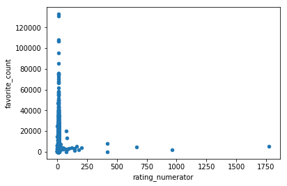

```python
df.plot.scatter(x='rating_numerator', y='favorite_count')
```

```python
df.to_csv("twitter_archive_master.csv",index=False)
```

```python
import pandas as pd
df=pd.read_csv("twitter_archive_master.csv")
```

```python
df.sample(20)
```

|  | id | timestamp | rating_numerator | rating_denominator | name | dog_stages | favorite_count | retweet_count | img_num | dog_breed | pred_conf | dog_breed_pred |
| --- | --- | --- | --- | --- | --- | --- | --- | --- | --- | --- | --- | --- |
| 1496 | 692530551048294401 | 2016-01-28 02:12:04 +0000 | 10 | 10 | Cody | NaN | 2021.0 | 474.0 | 1.0 | Siberian Husky | 0.486428 | True |
| 274 | 840698636975636481 | 2017-03-11 22:59:09 +0000 | 10 | 10 | None | NaN | 197.0 | 3.0 | NaN | NaN | NaN | NaN |
| 888 | 759846353224826880 | 2016-07-31 20:21:02 +0000 | 11 | 10 | Kirby | NaN | 7433.0 | 2265.0 | 1.0 | Sussex Spaniel | 0.355395 | True |
| 375 | 828361771580813312 | 2017-02-05 21:56:51 +0000 | 12 | 10 | None | NaN | 2408.0 | 195.0 | NaN | NaN | NaN | NaN |
| 1919 | 674269164442398721 | 2015-12-08 16:47:50 +0000 | 8 | 10 | Bob | NaN | 961.0 | 255.0 | 1.0 | Pug | 0.622921 | True |
| 1106 | 734787690684657664 | 2016-05-23 16:46:51 +0000 | 13 | 10 | None | NaN | 13745.0 | 7102.0 | 4.0 | Golden Retriever | 0.883991 | True |
| 1747 | 679111216690831360 | 2015-12-22 01:28:25 +0000 | 12 | 10 | officially | NaN | 6514.0 | 2893.0 | 1.0 | Kelpie | 0.189423 | True |
| 1229 | 713761197720473600 | 2016-03-26 16:15:05 +0000 | 12 | 10 | Piper | NaN | 5308.0 | 1541.0 | 1.0 | Brittany Spaniel | 0.797936 | True |
| 590 | 799297110730567681 | 2016-11-17 17:04:16 +0000 | 11 | 10 | Jeffrey | NaN | 11065.0 | 3227.0 | 1.0 | Malamute | 0.985028 | True |
| 2040 | 671544874165002241 | 2015-12-01 04:22:29 +0000 | 6 | 10 | None | NaN | 2126.0 | 1145.0 | 1.0 | Feather Boa | 0.240858 | False |
| 913 | 757400162377592832 | 2016-07-25 02:20:45 +0000 | 13 | 10 | None | NaN | 16743.0 | 7759.0 | 1.0 | Seat Belt | 0.523926 | False |
| 1616 | 685198997565345792 | 2016-01-07 20:39:06 +0000 | 11 | 10 | Alfie | NaN | 2566.0 | 764.0 | 1.0 | Dishwasher | 0.888829 | False |
| 1922 | 674255168825880576 | 2015-12-08 15:52:13 +0000 | 10 | 10 | Bobbay | NaN | 1581.0 | 619.0 | 1.0 | Eskimo Dog | 0.615741 | True |
| 933 | 753655901052166144 | 2016-07-14 18:22:23 +0000 | 10 | 10 | None | NaN | 6458.0 | 2492.0 | 1.0 | Miniature Pinscher | 0.456092 | True |
| 1770 | 678341075375947776 | 2015-12-19 22:28:09 +0000 | 12 | 10 | None | pupper | 1896.0 | 612.0 | 1.0 | Golden Retriever | 0.853284 | True |
| 606 | 798340744599797760 | 2016-11-15 01:44:00 +0000 | 11 | 10 | Davey | NaN | 0.0 | 3924.0 | 1.0 | Papillon | 0.533180 | True |
| 1282 | 708738143638450176 | 2016-03-12 19:35:15 +0000 | 11 | 10 | Coco | NaN | 2997.0 | 917.0 | 1.0 | Pomeranian | 0.933457 | True |
| 770 | 776819012571455488 | 2016-09-16 16:24:19 +0000 | 13 | 10 | None | pupper | 0.0 | 15839.0 | 3.0 | Chihuahua | 0.346545 | True |
| 233 | 847842811428974592 | 2017-03-31 16:07:33 +0000 | 12 | 10 | Rontu | NaN | 5935.0 | 1522.0 | 1.0 | Bernese Mountain Dog | 0.951337 | True |
| 1910 | 674416750885273600 | 2015-12-09 02:34:18 +0000 | 10 | 10 | Jonah | NaN | 731.0 | 157.0 | 1.0 | Chihuahua | 0.287201 | True |

```
Define
```

Set limit for x axis rating numerator to 20.

Code

```
(0, 20)
```

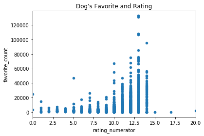

```python
df.plot.scatter(x='rating_numerator', y='favorite_count',title="Dog's Favorite and Rating")
plt.xlim(0,20)
```